# An Introduction to Spatial Data Analysis in R

## Types of data

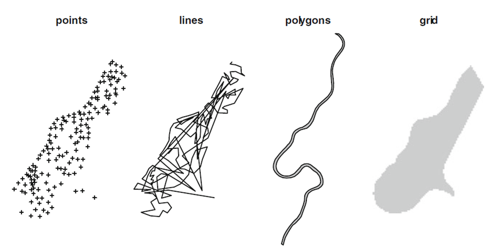

Source: Bivand et al. (2008)

## Main formats

- Vector: ESRI Shapefile (.shp +), Keyhole Markup Language (.kml/.kmz), geoJSON…
- Raster: GeoTIFF, ESRI Grid, JPEG2000…

## `R` packages

- rgdal
- raster
- sp
- rgeos
- mapview, basemaps, RgoogleMaps
- spdep, gstat, geoR

Run (e.g.) `install.packages('rgdal')`

## Example

```r
library(rgdal)
vistula = readOGR('shp_lessons/vistula_islands.shp', verbose = F)
vistula
```

```
## class       : SpatialPolygonsDataFrame
## features    : 2
## extent      : 489595.3, 493760.6, 5801413, 5803535  (xmin, xmax, ymin, ymax)
## crs         : +proj=utm +zone=34 +datum=WGS84 +units=m +no_defs
## variables   : 1
## names       :            Name
## min values  : northern_island
## max values  : southern_island
```

## Example

```r
abund = readOGR('shp_lessons/abundance_n.shp', verbose = F)
abund
```

```
## class       : SpatialPointsDataFrame
## features    : 672
## extent      : 490270.8, 491857.2, 5803253, 5803528  (xmin, xmax, ymin, ymax)
## crs         : +proj=utm +zone=34 +datum=WGS84 +units=m +no_defs
## variables   : 1
## names       : abundance
## min values  :         1
## max values  :         5
```

## Example

Polygons depicting river islands within the nature reserve area *Ławice Kiełpińskie*, north of Warsaw. Points contain data of plant communities abundance within 20 m radius.

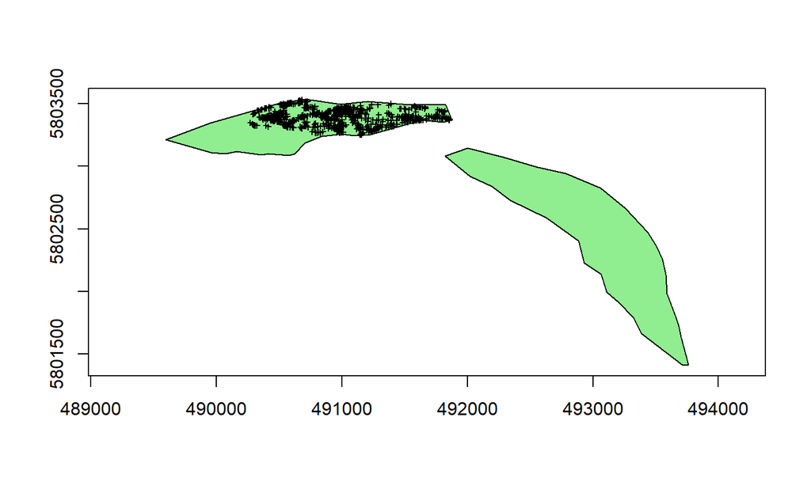

## Example

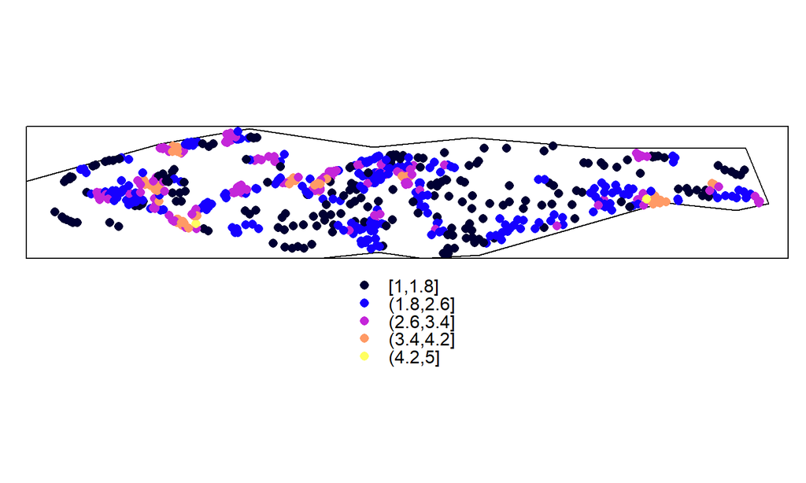

```r
spplot(abund, sp.layout = vistula)
```

## Objective

Learn how to retrieve data from vector data, check spatial autocorrelation, perform spatial interpolation in a R.O.I., visualize and save a map in a raster file using `R`.

## Spatial autocorrelation

- Moran’s I

\[I = \frac{n}{\sum_{i=1}^n (z_i - \bar{z})^2} \frac{\sum_{i=1}^n \sum_{j=1}^n w_{ij}(z_i - \bar{z})(z_j - \bar{z})}{\sum_{i=1}^n \sum_{j=1}^n w_{ij}}\]

\(z_i\) (and \(z_j\)) is a spatial observation, \(w_{ij}\) is a spatial weight for the link between \(i\) and \(j\).

## Spatial weights

```r
coords = coordinates(abund)
gd = pointDistance(coords, lonlat = FALSE)
dim(gd)
```

```
## [1] 672 672
```

```r
W = 1/gd      # example of weighting matrix
diag(W) <- 0  # to remove Inf
W[1:4, 1:4]
```

```
##           [,1]      [,2]      [,3]      [,4]
## [1,] 0.0000000 0.2451591 0.1992722 0.1692720
## [2,] 0.2451591 0.0000000 0.2076518 0.4861555
## [3,] 0.1992722 0.2076518 0.0000000 0.2062171
## [4,] 0.1692720 0.4861555 0.2062171 0.0000000
```

## Moran’s I test

\(H_0: I = E(I) = -1/(n-1)\) vs. \(H_1: I > E(I)\)

```r
library(spdep)
wl = mat2listw(W)
moran.test(abund$abundance, listw = wl)
```

```
##
##  Moran I test under randomisation
##
## data:  abund$abundance
## weights: wl
##
## Moran I statistic standard deviate = 40.251, p-value < 2.2e-16
## alternative hypothesis: greater
## sample estimates:
## Moran I statistic       Expectation          Variance
##      2.137609e-01     -1.490313e-03      2.859874e-05
```

## Changing weights for neighbourhood

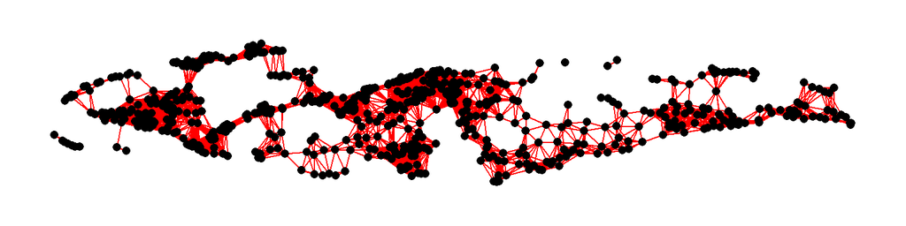

```r
W2 = gd < 50  # meters
wl2 = mat2listw(W2)
par(mar = c(1,1,1,1))
plot(wl2, coords, col = 'red', pch = 16)
```

## Moran’s I test

```r
moran.test(abund$abundance, listw = wl2)
```

```
##
##  Moran I test under randomisation
##
## data:  abund$abundance
## weights: wl2
##
## Moran I statistic standard deviate = 35.344, p-value < 2.2e-16
## alternative hypothesis: greater
## sample estimates:
## Moran I statistic       Expectation          Variance
##      0.3746283577     -0.0014903130      0.0001132419
```

## Spatial correlogram

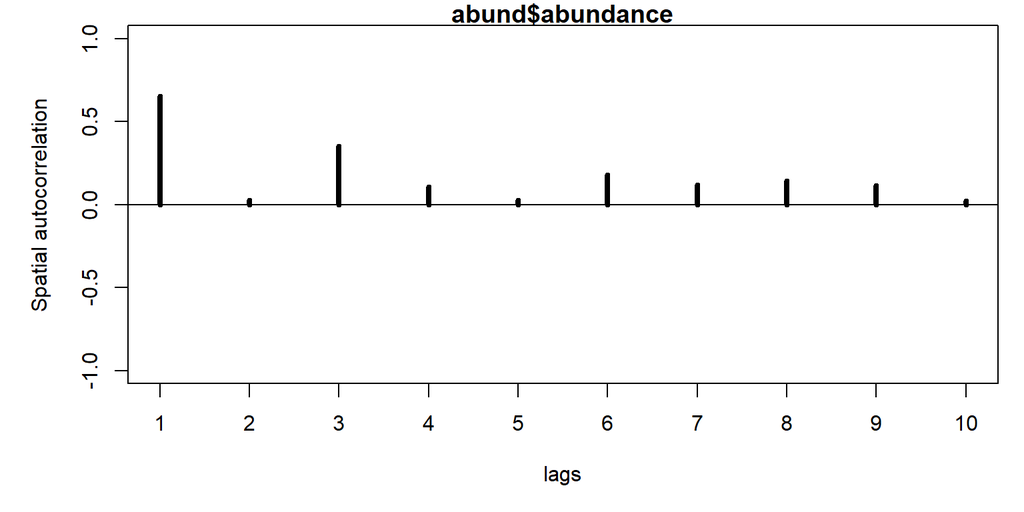

```r
nb <- dnearneigh(abund, d1 = 0, d2 = 50)
scor <- sp.correlogram(nb, var = abund$abundance, order = 10,
                       method = "corr", zero.policy = TRUE)
par(mar = c(5,5,1,1)); plot(scor)
```

## Clusters and Hotspots

- Clusters: observations with very similar neighbours
- Hotspots: observations with very different neighbours

Those can be detected by breaking the global statistics (e.g. Moran’s I) into its *n* components:

\[I_i = \frac{n(z_i - \bar{z})\sum_{j=1}^n w_{ij}(z_j - \bar{z})}{\sum_{i=1}^n (z_i - \bar{z})^2}\]

## Local Moran’s I

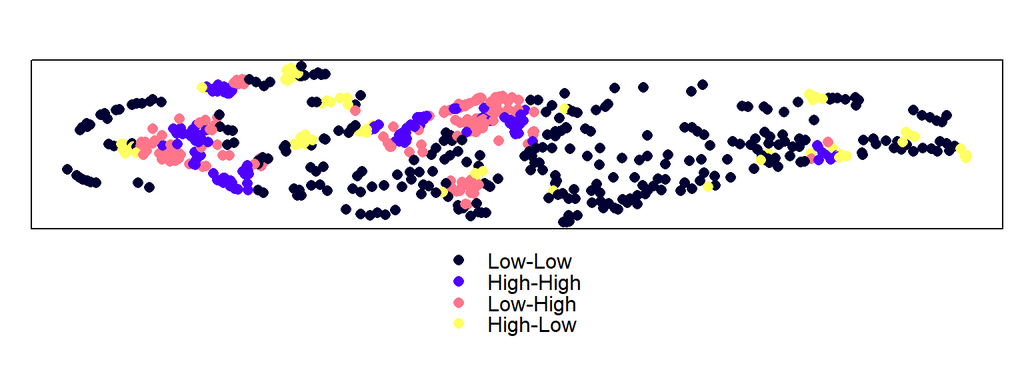

```r
locI = localmoran(abund$abundance, wl2)
abund$quadr = factor(attr(locI, 'quadr')$mean,
                      levels = c('Low-Low', 'High-High',
                                 'Low-High', 'High-Low'))
par(mar = c(1,1,1,1))
spplot(abund, zcol = 'quadr')
```

## Spatial interpolation

- Non-geostatistical (IDW, Trend analysis - regression…)
- Geostatistical (Kriging)

## Inverse Distance Weighting

\[\hat{z}(s_k) = \frac{\sum_{i=1}^n w(s_i)z(s_i)}{\sum_{i=1}^n w(s_i)}\]

where \(w(s_i) = ||s_k - s_i||^{-p}\), and usually \(p = 2\)

## Prediction grid

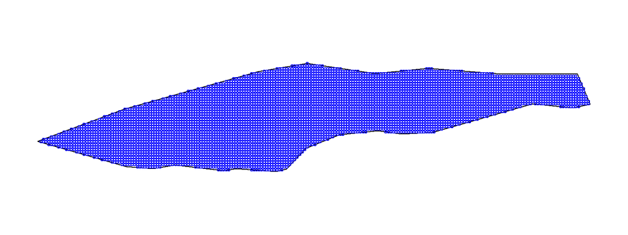

```r
north = subset(vistula, Name == 'northern_island')
gr = spsample(north, n = 5000, type = 'regular')
colnames(attr(gr, 'coords')) = c('x', 'y')
gridded(gr) = TRUE
crs(gr) = crs(north)
par(mar = c(1,1,1,1)); plot(north)
points(gr, cex = 0.5, col = 'blue')
```

## IWD interpolation

```r
colnames(attr(abund, 'coords')) = c('x', 'y')
library(gstat)
pred_idw = idw(abundance ~ 1, abund, newdata = gr, idp = 2)
```

```
## [inverse distance weighted interpolation]
```

## Prediction map

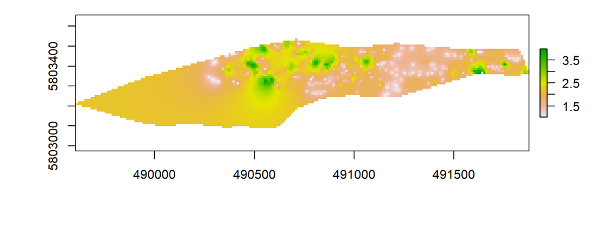

```r
r = raster(pred_idw)
par(mar = c(5,5,1,1))
plot(r)
```

```r
# writeRaster(r, filename = 'map_north.tif')
```

## References

- Bivand et al. (2008). Applied spatial data analysis with R (Vol. 747248717, pp. 237-268). New York: Springer. URL https://link.springer.com/book/10.1007/978-1-4614-7618-4
- Lovelace et al. (2017). Introduction to visualising spatial data in R. Available from: https://cran.r-project.org/doc/contrib/intro-spatial-rl.pdf